# Cheking the folmulae for GxE

Andrey Ziyatdinov

2016-12-20

# 1 About

There are a list of formulae to estimate the (covariate) effect and its variance under different scenarios:

- marginal and interaction effects;
- variance of random vectors are estimated either directly via `var` function or by using parameters of binomial distribution;
  - for example, the variance of the genotype is `var(g) = 2 p (1-p)`, where `p` is MAF;
  - when working on power of the test, the use of `p` and others is of the interest;
- linear and mixed linear models.

Some expectations to be confirmed by simulations:

- The larger sample size the less variance in estimation of the effects.
- Using formulae like `var(g) = 2 p (1-p)` is less accurate than using directly `var` function.
  - The larger sample size the better approximation.
- When testing interaction, an artificial setting of forcing marginal effects to zero is possible. That will lead to less noise in estimation of mean effecs (only global mean *vs.* global mean and the two marginal effecs).

# 2 Model of marginal effect

## 2.1 Model

- A single variable, e.g. genotype `G`, is represented in a 1-column matrix $X$.
- The derivation works when variable in `X` is not scaled.

$Y \sim \mathcal{N}(\mu 1_n + X \beta, \sigma_e^2 I)$

$\hat{\beta} = (X^T X)^{−1} X^T Y \sim \mathcal{N}(\beta, \frac{\sigma_e^2}{X^T X}) = \mathcal{N}(\beta, \frac{\sigma_e^2}{N \sigma_X^2})$

If `G` is a genotype with MAF `p`, then

$\hat{\beta} \sim \mathcal{N}(\beta, \frac{\sigma_e^2}{N 2p(1-p)})$

## 2.2 Simulation

- The number of simulations is 100.
- The smaple size is 100, 1,000 or 5,000.
- The effect $\beta$ is 0.1.
- The residual variance is 1.
- `p` is 0.3.

R code for simulation:

```
g <- sample(c(0, 1, 2), size = N, prob = c(q^2, 2*p*q, p^2), replace = TRUE)
y <- beta * g + rnorm(N)

mod <- lm(y ~ g)
```

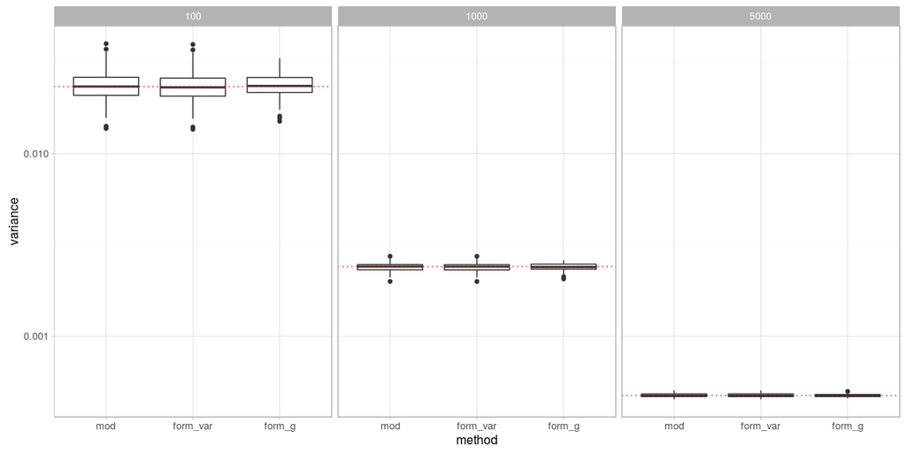

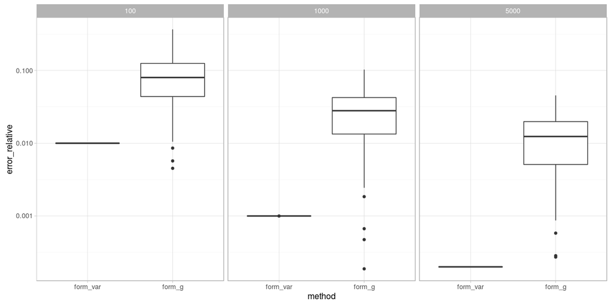

# 3 Model of interaction effect

## 3.1 Model

- The matrix of covariates `X` now has three columns: genotype `G`, exposure `E` and interaction `G*E`.
- In simulations with zero marginal effects, the derivation for a single covariate is re-used (?).
  - Again, this derivation works when a single variable in `X` (`G*E`) is not scaled.

$Y \sim \mathcal{N}(\mu 1_n + X \beta, \sigma_e^2 I)$

$\hat{\beta} = (X^T X)^{−1} X^T Y \sim \mathcal{N}(\beta, \frac{\sigma_e^2}{X^T X}) = \mathcal{N}(\beta, \frac{\sigma_e^2}{N \sigma_X^2})$

If `G` and `E` are independent, then

$\sigma_X^2 = \sigma_{GE}^2 = \sigma_G^2 \sigma_E^2 + \sigma_G^2 \mu_E^2 + \sigma_E^2 \mu_G^2 \approx \sigma_G^2 \sigma_E^2$

Finally,

$\hat{\beta} \sim \mathcal{N}(\beta, \frac{\sigma_e^2}{N \sigma_{GE}^2}) \approx \mathcal{N}(\beta, \frac{\sigma_e^2}{N \sigma_{G}^2 \sigma_{E}^2})$

## 3.2 Simulation

R code for simulation:

```
g <- sample(c(0, 1, 2), size = N, prob = c(q^2, 2*p*q, p^2), replace = TRUE)
e <- rbinom(N, 1, f)
ge <- g*e
ge_c <- (g - mean(g))*(e - mean(e))

y <- beta * ge + rnorm(N)

mod1 <- lm(y ~ ge_c)
mod2 <- lm(y ~ g + e + g:e)

sigma1 <- sqrt(deviance(mod1) / (nobs(mod1) - length(coef(mod1))))
sigma2 <- sqrt(deviance(mod2) / (nobs(mod2) - length(coef(mod2))))

var_i_mod = vcov(mod1)["ge_c", "ge_c"]
var_c_mod = vcov(mod2)["g:e", "g:e"]

r_i_form_var = sigma1^2 / (N*var(ge_c))
var_c_form_var = sigma2^2 / (N*var(ge_c))

var_i_form_var_a = sigma1^2 / (N*var(g)*var(e))
var_c_form_var_a = sigma2^2 / (N*var(g)*var(e))

var_i_form_ge = sigma1^2 / (N*2*p*q*f*(1-f))
var_c_form_ge = sigma2^2 / (N*2*p*q*f*(1-f))
```

- It is well known that it is erroneous to test for inteaction in absence of marginal effects, even if data were simulated such as `y <- beta * g * e + rnorm(N)`.
  - The following model `mod1 <- lm(y ~ ge_c)` works, becaus of the hack of mean-centering of `g` and `e` (`ge_c <- (g - mean(g))*(e - mean(e))`) before fitting the model.
- The same way `var(g)*var(e)` is equal to `var(ge_c)` rather than `var(ge)`. See the formula to compute variance of a product of two random variables.

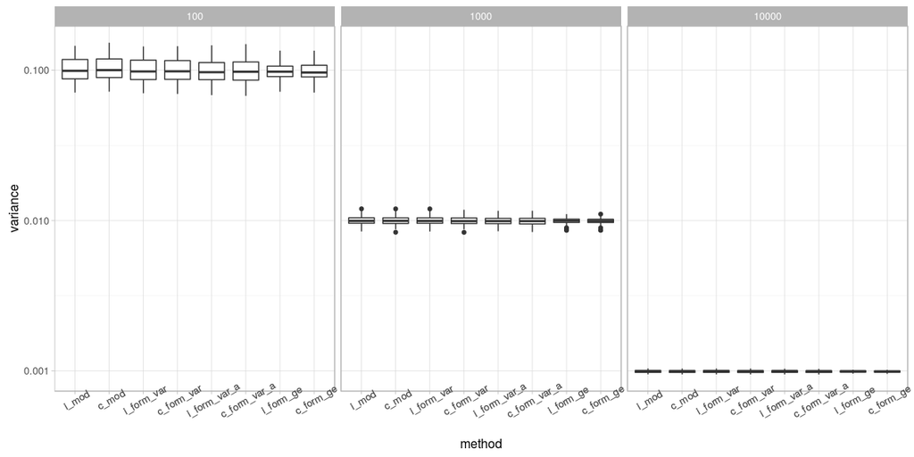

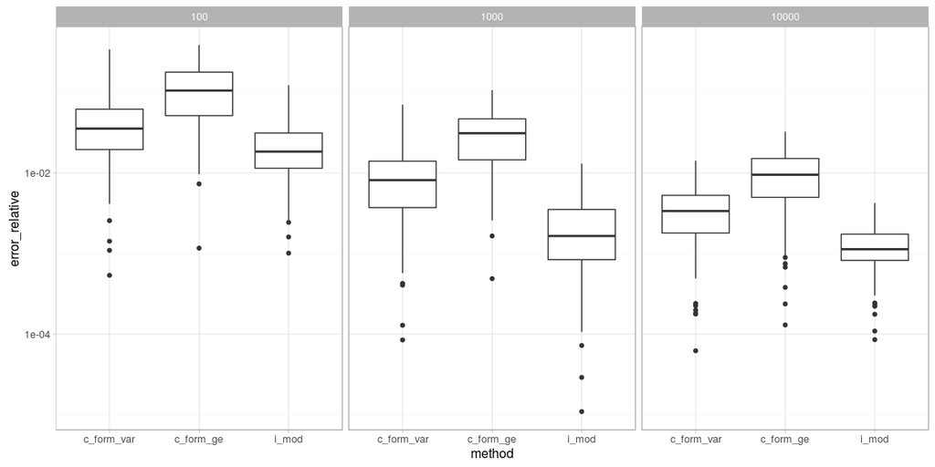